# CDS 101 – Final Project Report

Ankith Kolapalli, Julia Conway, Ruhama

December 08, 2025

# 1 1. Problem Definition

This question is interesting because it allows us to see trends and patterns between different variables like engine type and mileage in relation to the price of the vehicle as a whole.

Our main objectives include cleaning the data, fixing missing values, and creating visualizations such as bar plots and scatter plots.

Key assumptions that we have made are that certain features, especially car year, mileage, and engine size will strongly relate to price. Newer cars and cars with bigger engines will cost more, while cars with high mileage will usually be priced lower. Fuel type and transmission also show clear price differences. Overall, we expect the multiple regression model to perform better than the simple model because it captures more variables that influence price.

# 2 2. Data Acquisition & Description

Data Set Name: CarDekho Vehicle Dataset Source: Kaggle (https://www.kaggle.com/datasets/nehalbirla/vehicle-dataset-from-cardekho) Variable description: the dataset has car features like brand, body type, engine type, distance, registration, and price.  
Size: around 4,300 rows with 9 coloumns

```r
library(readr)
library(dplyr)
```

```r
library(ggplot2)
cars_raw <- read_csv("data/cars_data.csv")
```

# 3 3. Data Cleaning & Preprocessing

```r
cars_clean <- cars_raw %>%
  filter(!is.na(Price), !is.na(Brand)) %>%
  rename(EngineType = `Engine Type`) %>%
  mutate(Brand = factor(Brand),
         Body = factor(Body),
         EngineType = factor(EngineType),
         Registration = factor(Registration)
  )
```

# 4 4. Exploratory Data Analysis (EDA)

This section maps directly to the **EDA** part of the rubric:

- Summary statistics
- Visualizations
- Interpretation connected to the research question

```r
library(dplyr)
summary(cars_clean)
```

```
##            Brand         Price               Body         Mileage
##  Audi         :442   Min.   :   600   crossover: 840   Min.   :  0.0
##  BMW          :669   1st Qu.:  6999   hatch    : 279   1st Qu.: 90.0
##  Mercedes-Benz:852   Median : 11500   other    : 418   Median :158.0
##  Mitsubishi   :323   Mean   : 19419   sedan    :1604   Mean   :164.1
##  Renault      :456   3rd Qu.: 21700   vagon    : 390   3rd Qu.:230.0
##  Toyota       :523   Max.   :300000   van      : 642   Max.   :980.0
##  Volkswagen   :908
##     EngineV        EngineType   Registration      Year         Model
##  Min.   : 0.600   Diesel:1903   no : 394     Min.   :1969   Length:4173
##  1st Qu.: 1.800   Gas   : 606   yes:3779     1st Qu.:2003   Class :character
##  Median : 2.200   Other : 150                Median :2007   Mode  :character
##  Mean   : 2.765   Petrol:1514                Mean   :2006
##  3rd Qu.: 3.000                              3rd Qu.:2012
##  Max.   :99.990                              Max.   :2016
##  NA's   :148
```

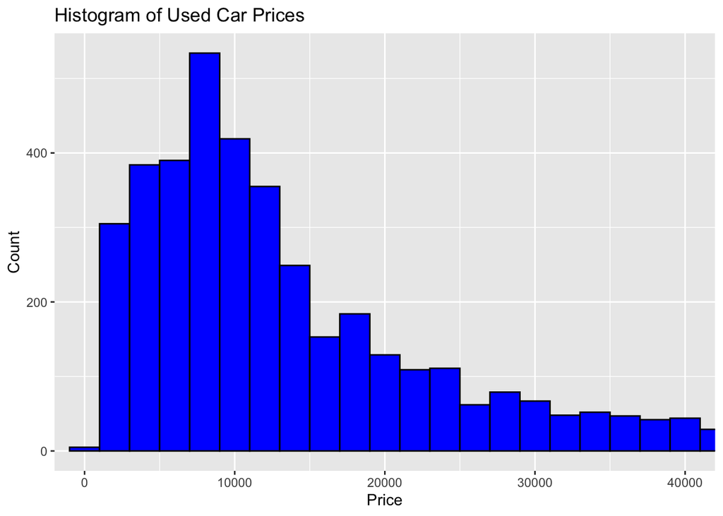

```r
ggplot(cars_clean) +
  geom_histogram(mapping = aes(x = Price),binwidth = 2000,color = "black",fill  = "blue") +
  coord_cartesian(xlim = c(0, 40000)) +
  labs(title = "Histogram of Used Car Prices",
       x = "Price",
       y = "Count"
  )
```

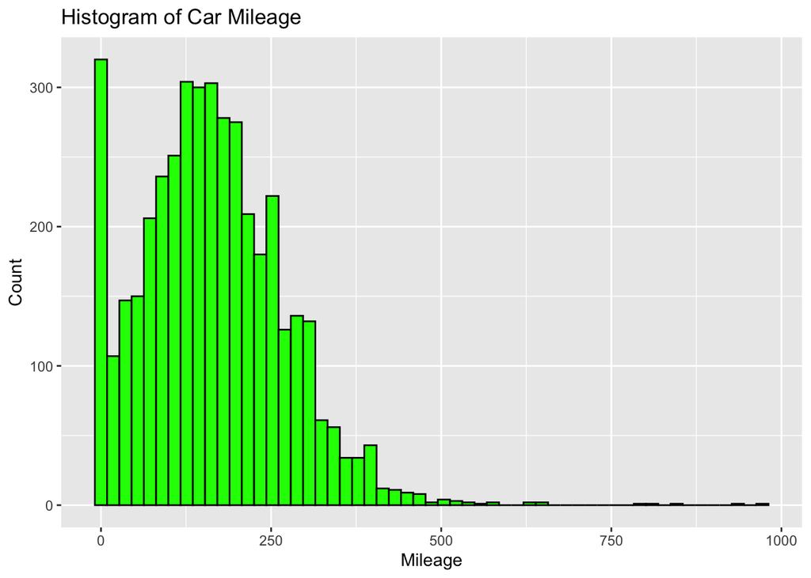

```r
ggplot(cars_clean) +
  geom_histogram(mapping = aes(x = Mileage),binwidth = 18,color = "black",fill  = "green") +
  labs(title = "Histogram of Car Mileage",
       x = "Mileage",
       y = "Count"
  )
```

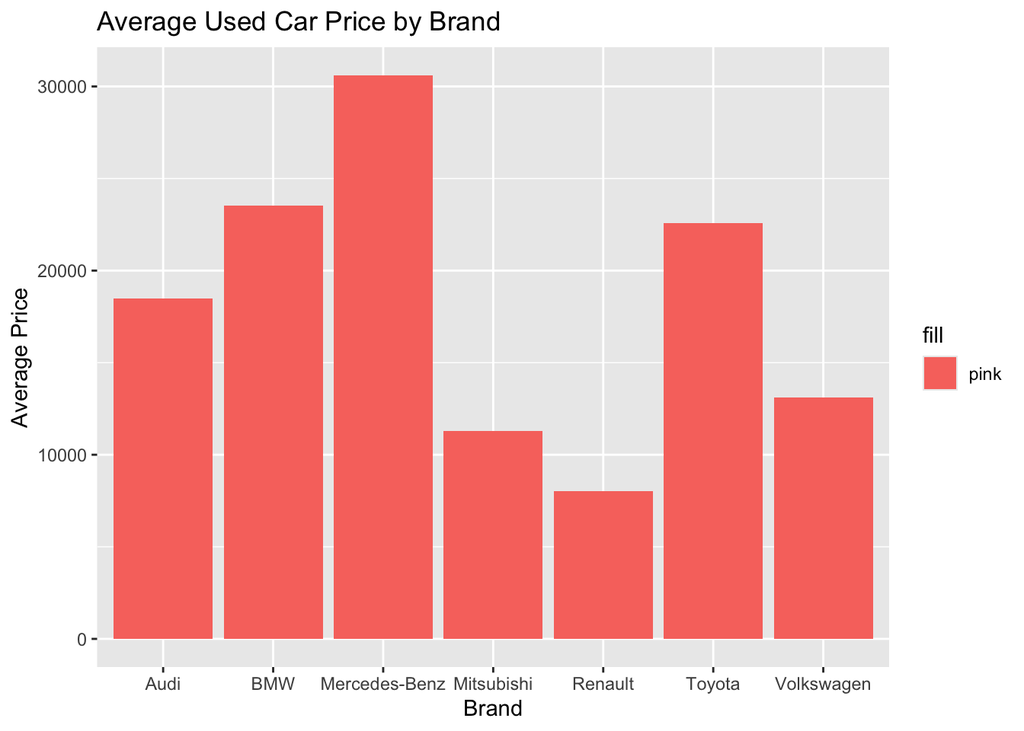

```r
avg_price<- cars_clean %>%
  group_by(Brand) %>%
  summarise(mean_price = mean(Price, na.rm = TRUE)) %>%
  arrange(mean_price)

ggplot(avg_price) +
  geom_col(mapping = aes(x = Brand, y = mean_price, fill = "pink")) +
  labs(title = "Average Used Car Price by Brand",
       x = "Brand",
       y = "Average Price"
  )
```

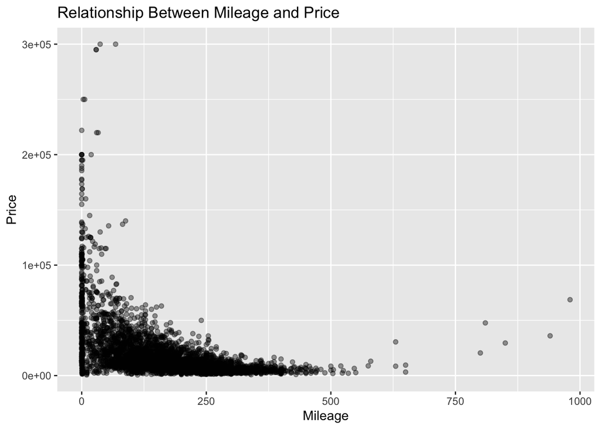

```r
ggplot(cars_clean) +
  geom_point(mapping = aes(x = Mileage, y = Price),
    alpha = 0.4) +
  labs(title = "Relationship Between Mileage and Price",
       x = "Mileage",
       y = "Price"
  )
```

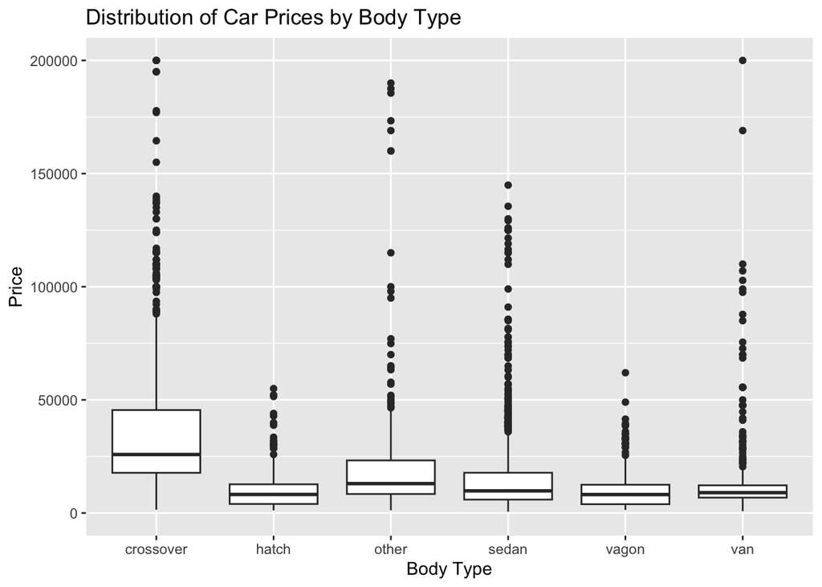

```r
ggplot(cars_clean) +
  geom_boxplot(mapping = aes(x = Body, y = Price)) +
  coord_cartesian(ylim = c(0, 200000)) +
  labs(title = "Distribution of Car Prices by Body Type",
       x = "Body Type",
       y = "Price"
  )
```

# 5. Visualization Quality and Storytelling

Histograms specifically help us to visualize distributions within our data set which can help us understand how our outlined variables affect vehicle pricing. Utilizing bar graphs helped us see how the average prices changed across specific car models, and scatter plotting helped us visualize what kind of influence our variables had over increasing or decreasing prices. Boxplots are appropriate to our research as well because they illustrate outliers, and help us see things like the median and maximum values easier.

Upon making our graphs, we tried our best to use titles that were an accurate depiction of what the graph was showcasing as well as labeling our axis concisely. Ultimately we didn’t really make use of many legends because most of our graphs were very simplistic and didn’t require one… for example our first and second graphs only contained one variable and one color. Similar to this, our color choices were very straight forward and were chosen ensure readability and deter any confusion.

Additionally, we used increments in our graphs that were simplistic and appropriate for mileage and price…the price went up in increments of 10,000 and the mileage went up in increments of 250. For the different car models we used no more than seven to ensure that we weren’t decreasing the legitimacy of our analysis by having too many areas of focus.